# Welcome

### Biostatistics Essentials: a blackboard approach

- 21st - 23rd, May, 2019
- SciLifeLab, Uppsala University, BMC, Husargatan 3, E10:1308

### Getting to know each other

##### Teaching team

- [Eva Freyhult](https://nbis.se/about/staff/eva-freyhult/), PhD, NBIS, SciLifeLab, Uppsala University
- [Olga Dethlefsen](https://nbis.se/about/staff/olga-dethlefsen/), PhD, NBIS, SciLifeLab, University of Stockholm
- [Payam Emami](https://nbis.se/about/staff/payam-emami/), PhD, NBIS, SciLifeLab, University of Stockholm
- [Paulo Czarnewski](https://nbis.se/about/staff/paulo-czarnewski/), PhD, NBIS, SciLifeLab, University of Stockholm
- [Marcin Kierczak](https://nbis.se/about/staff/marcin-kierczak/), PhD, NBIS, SciLifeLab, Uppsala University
- [Bengt Sennblad](https://nbis.se/about/staff/bengt-sennblad/), PhD, NBIS, SciLifeLab, Uppsala University
- [Warren Kretzschmar](https://ki.se/en/people/warkre), PhD, Department of Medicine, Huddinge, Karolinska Institutet

#### What about you?

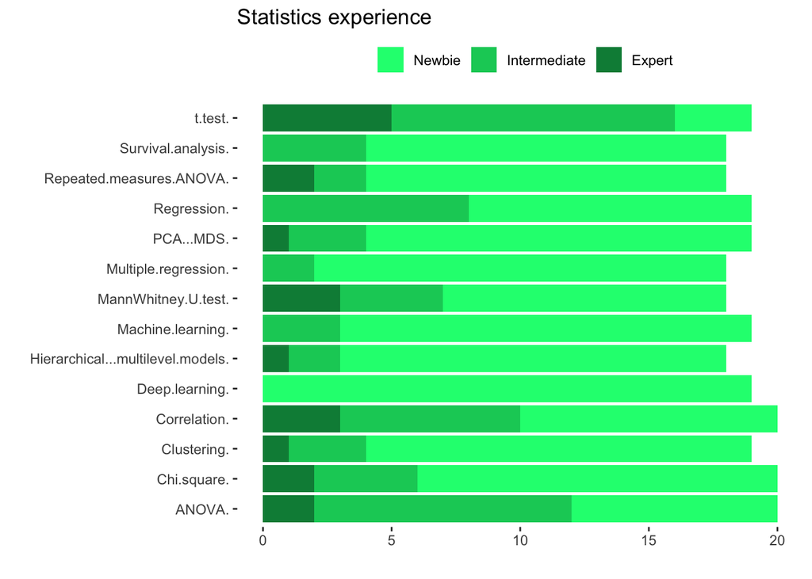

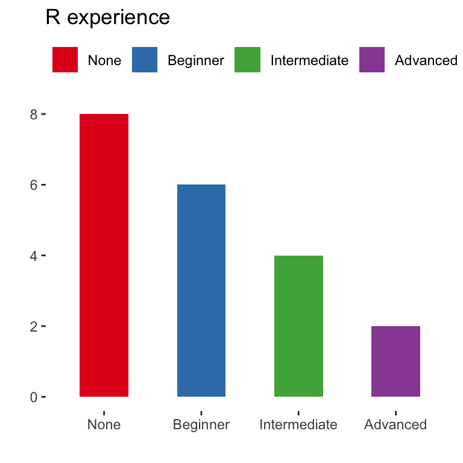

### Teaching philosophy aka. “blackboard approach”

*In this course we focus on active learning approach. The course participants are expected to do some pre-course reading and exercises, corresponding up to 16h studying. The education consists of teaching blocks alternating between mini-lectures, group discussions, live coding sessions etc. A special focus is put on understanding basic concepts by solving problems with pen and paper. We believe in less-is-more principle, so be ready to say no to digital exhaustion to truly learn something with our modern “blackboard approach”*

- Focus on active learning
- To develop comptetency and capture attention
- Drawing from education theory (behavourist, neuroscience, cognitivism, social learning, humanistic principles)

### Course website:

https://nbisweden.github.io/workshop-biostatistics/